# Landscape of Change Results

## How have bird species populations changed from 1880 to now?

### Summary

Bird species abundance and diversity has certainly changed between now and the 1880’s when the Champlain Society was running field courses on Mount Desert Island (MDI). We compared the Champlain Society’s species list that they kept over the 4 year duration they were active on MDI, to the past 4 years of eBird data from 2018-2021. Since the effort of birders today is much more extensive than what could have been possible in the 1880’s lets compare the species diversity of common species. Today, there are 87 common species on MDI, whereas in the early 1880’s there were only 58 common species. So, the diveristy of regularly occuring species has increased. **Table 3** lists all species that were not recorded historically, but are now common. When looking at the changes of the species recorded historically we do see a drastic 25% decrease in these species (**Fiugre 1**, **Table 1**). For a full list of changes to species see **Table 2**.

### Bar Graph of Species Changes

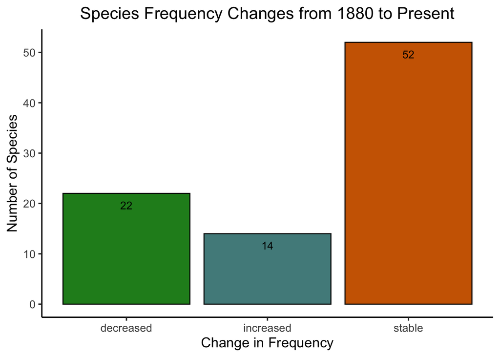

**Figure 1**. The bar graph shows changes in the species recorded by the Champlain Society in the 1880s.

### Species That Decreased

**Table 1**. This table shows the species we know to have descreased in abundance since the 1880s. The frequency value ‘migrant only’ refers to the species not breeding on MDI and isn’t specifically associated with migratory species.

| common.name | scientific.name | frequency.1880 | frequency.current | frequency.changes |
| --- | --- | --- | --- | --- |
| American Woodcock | Scolopax minor | common | rare | decreased |
| Bank Swallow | Riparia riparia | common | rare | decreased |
| Bay-breasted Warbler | Setophaga castanea | common | uncommon | decreased |
| Black-billed Cuckoo | Coccyzus erythropthalmus | common | rare | decreased |
| Black-crowned Night-Heron | Nycticorax nycticorax | common | migrant only | decreased |
| Black-legged Kittiwake | Rissa tridactyla | uncommon | migrant only | decreased |
| Boreal Chickadee | Poecile hudsonicus | rare | migrant only | decreased |
| Canada Warbler | Cardellina canadensis | common | rare | decreased |
| Chimney Swift | Chaetura pelagica | common | rare | decreased |
| Common Nighthawk | Chordeiles minor | common | uncommon | decreased |
| Eastern Kingbird | Tyrannus tyrannus | uncommon | rare | decreased |
| Indigo Bunting | Passerina cyanea | rare | migrant only | decreased |
| Nashville Warbler | Leiothlypis ruficapilla | common | uncommon | decreased |
| Pied-billed Grebe | Podilymbus podiceps | rare | migrant only | decreased |
| Pine Siskin | Spinus pinus | common | rare | decreased |
| Ring-necked Duck | Aythya collaris | rare | migrant only | decreased |
| Ruffed Grouse | Bonasa umbellus | common | rare | decreased |
| Wilson’s Warbler | Cardellina pusilla | rare | migrant only | decreased |
| Yellow-bellied Flycatcher | Empidonax flaviventris | common | rare | decreased |
| Eastern Whip-poor-will | Antrostomus vociferus | rare | not present | decreased |
| Cliff Swallow | Petrochelidon pyrrhonota | common | not present | decreased |
| Purple Martin | Progne subis | rare | not present | decreased |

### Total Species List Changes

**Table 2**. This table breaks down of all species recorded by the Champlain Society with their frquency status from the 1880s and today. If you look at the ‘Changes in Frequency’ column you can see how these species have changed from historic times.

| common.name | scientific.name | frequency.1880 | frequency.current | frequency.changes |
| --- | --- | --- | --- | --- |
| Alder Flycatcher | Empidonax alnorum | common | common | stable |
| American Bittern | Botaurus lentiginosus | rare | uncommon | increased |
| American Black Duck | Anas rubripes | common | common | stable |
| American Crow | Corvus brachyrhynchos | common | common | stable |
| American Goldfinch | Spinus tristis | common | common | stable |
| American Redstart | Setophaga ruticilla | common | common | stable |
| American Robin | Turdus migratorius | common | common | stable |
| American Woodcock | Scolopax minor | common | rare | decreased |
| Bald Eagle | Haliaeetus leucocephalus | common | common | stable |
| Bank Swallow | Riparia riparia | common | rare | decreased |
| Barn Swallow | Hirundo rustica | common | common | stable |
| Barred Owl | Strix varia | uncommon | common | increased |
| Bay-breasted Warbler | Setophaga castanea | common | uncommon | decreased |
| Belted Kingfisher | Megaceryle alcyon | common | common | stable |
| Black Guillemot | Cepphus grylle | common | common | stable |
| Black Scoter | Melanitta americana | rare | uncommon | increased |
| Black-and-white Warbler | Mniotilta varia | common | common | stable |
| Black-billed Cuckoo | Coccyzus erythropthalmus | common | rare | decreased |
| Black-capped Chickadee | Poecile atricapillus | common | common | stable |
| Black-crowned Night-Heron | Nycticorax nycticorax | common | migrant only | decreased |
| Black-legged Kittiwake | Rissa tridactyla | uncommon | migrant only | decreased |
| Black-throated Blue Warbler | Setophaga caerulescens | rare | common | increased |
| Black-throated Green Warbler | Setophaga virens | common | common | stable |
| Blackburnian Warbler | Setophaga fusca | common | common | stable |
| Blue Jay | Cyanocitta cristata | rare | common | increased |
| Blue-headed Vireo | Vireo solitarius | common | common | stable |
| Bobolink | Dolichonyx oryzivorus | uncommon | uncommon | stable |
| Bonaparte’s Gull | Chroicocephalus philadelphia | uncommon | common | increased |
| Boreal Chickadee | Poecile hudsonicus | rare | migrant only | decreased |
| Broad-winged Hawk | Buteo platypterus | common | common | stable |

[output cut: 58 more lines]

### Modern Species Not Recorded in the 1880s

**Table 3**. This table shows the common and uncommon species that are reguarly seen on MDI in modern times, but were not recorded in the 1880s. From this, we can infer that these species have expanded their range likely as a result of cliamte change and landscape change. There are 31 species that are now common on MDI that were not present historically, and 15 species that are uncommon but regular and were not present historically.

| common.name | scientific.name | frequency |
| --- | --- | --- |
| Canada Goose | Branta canadensis | common |
| Cape May Warbler | Setophaga tigrina | uncommon |
| Common Eider | Somateria mollissima | common |
| Common Grackle | Quiscalus quiscula | common |
| Common Merganser | Mergus merganser | uncommon |
| Common Raven | Corvus corax | common |
| Cooper’s Hawk | Accipiter cooperii | uncommon |
| Double-crested Cormorant | Nannopterum auritum | common |
| Eastern Towhee | Pipilo erythrophthalmus | common |
| Eastern Wood-Pewee | Contopus virens | common |
| European Starling | Sturnus vulgaris | uncommon |
| Gray Catbird | Dumetella carolinensis | common |
| Great Black-backed Gull | Larus marinus | common |
| Great Crested Flycatcher | Myiarchus crinitus | uncommon |
| Great Egret | Ardea alba | uncommon |
| Hooded Merganser | Lophodytes cucullatus | common |
| House Finch | Haemorhous mexicanus | common |
| House Sparrow | Passer domesticus | common |
| Laughing Gull | Leucophaeus atricilla | common |
| Least Flycatcher | Empidonax minimus | uncommon |
| Mallard | Anas platyrhynchos | common |
| Merlin | Falco columbarius | common |
| Mourning Dove | Zenaida macroura | common |
| Nelson’s Sparrow | Ammospiza nelsoni | uncommon |
| Northern Cardinal | Cardinalis cardinalis | common |
| Northern Gannet | Morus bassanus | common |
| Palm Warbler | Setophaga palmarum | uncommon |
| Peregrine Falcon | Falco peregrinus | common |
| Pileated Woodpecker | Dryocopus pileatus | common |
| Pine Warbler | Setophaga pinus | common |
| Ring-billed Gull | Larus delawarensis | common |
| Rock Pigeon | Columba livia | common |
| Ruby-crowned Kinglet | Corthylio calendula | uncommon |
| Snowy Egret | Egretta thula | uncommon |
| Swamp Sparrow | Melospiza georgiana | common |
| Tennessee Warbler | Leiothlypis peregrina | uncommon |
| Tufted Titmouse | Baeolophus bicolor | uncommon |
| Turkey Vulture | Cathartes aura | common |
| Veery | Catharus fuscescens | uncommon |
| White-breasted Nuthatch | Sitta carolinensis | common |
| White-winged Scoter | Melanitta deglandi | common |
| Wild Turkey | Meleagris gallopavo | common |
| Wilson’s Storm-Petrel | Oceanites oceanicus | common |
| Wood Duck | Aix sponsa | common |
| Wood Thrush | Hylocichla mustelina | common |
| Yellow-bellied Sapsucker | Sphyrapicus varius | uncommon |